# Preliminary analysis of particle placement experiment

Jason Grafmiller

14 January, 2021

This is a quick preliminary analysis of the results from out particle placement 100-split rating task experiments.

**Quick Summary**

- We find a significant positive correlation between corpus model predictions and experimental ratings.
- We find a significant main effect of Direct Object length on the experimental ratings. The split variant is disfavored as the direct object gets longer, just as in the corpus model.
- We find a significant main effect of Country. IN participants tend to prefer the continuous variant slightly more than the GB participants.
- No interaction effects of Country and either Dir Obj length or Corpus predictions are found in a GLMM analysis. On the other hand, a GAMM analysis suggests that GB and IN participants do indeed show minor, yet significantly different, trends in their ratings over both Direct Object length and corpus model probabilities. These are very minor differences however, and I don’t think we should read too much into them for now.
- A few verbs show large differences in mean preferences between IN and GB participants, but for most verbs participants’ constructional preferences generally agree.

# 1 Visualize the data

## 1.1 Corpus predictions vs. ratings in aggregate

First we can look at the correlations between the predicted log odds from the corpus model and the ratings overall. We can consider different smoothers, to see whether there is any nonlinearity that we should account for. The plot shows that there clearly is a positive correlation (*r* = 0.48).

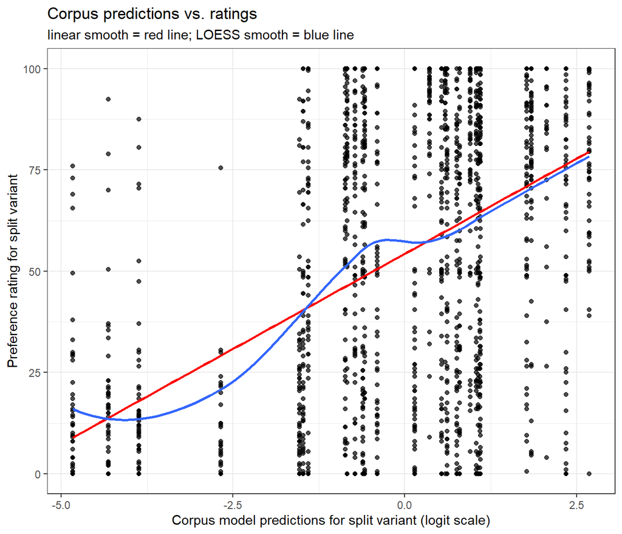

Now if we average over the individual verbs in the stimuli, we can see a little better.

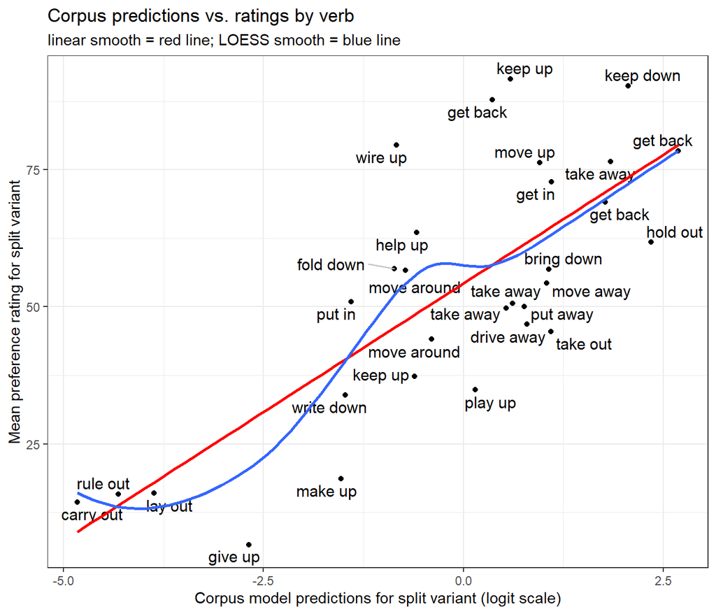

The relationship appears to be surprisingly (to me at least) linear.

If we separate the ratings by Country (with GAM smooths), the pattern really doesn’t change much.

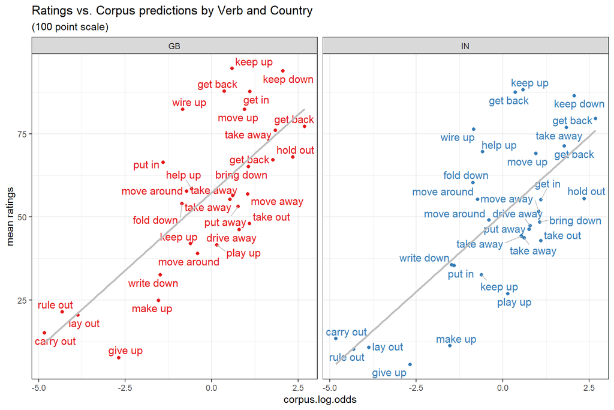

Standardizing doesn’t change the distribution of the response, only the scale, nor does transforming the ratings to the logit scale. But I think you can see a bit more clearly that the GB participants (left, in red) do tend to rate the split variants higher on average than the IN participants.

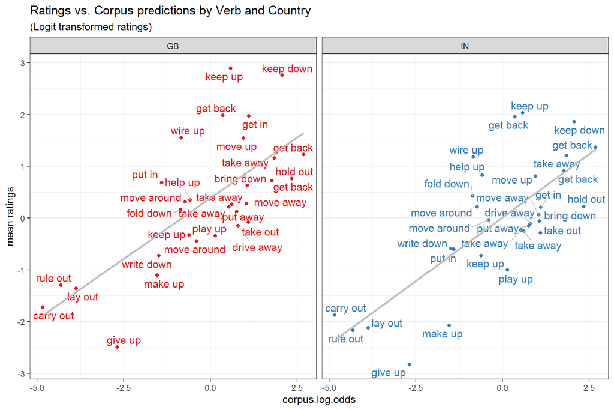

## 1.2 Lexical patterns

Do the GB and IN participants rate verbs the same way? It’s worth looking at the individual items and seeing where the different groups might diverge. In the plot below, the dots represent the mean rating across participants from the respective countries, and the segments connecting the dots represent the difference between the GB and IN participants for the given verb.

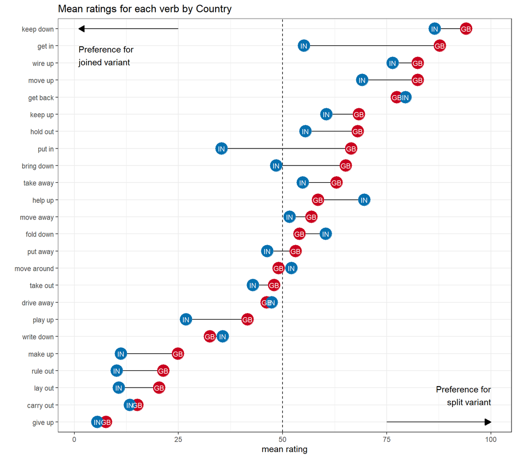

From the plot, it seems that for most verbs, the IN participants favor the joined/continuous variant more than the GB participants. In most cases the differences are not large, but for a few verbs (*put in*, *get in*, *bring down*) there is a substantial difference between the IN and GB participants on the order of 20-30 points or more.

We can also inspect the full distributions of the ratings for each verb across all participants. It’s clear that there are some verbs/tokens that everyone seems to agree on, e.g. *give up* and *keep down*, and others for which there is less agreement (those near the middle of the plot , e.g. *put away* and *drive away*).

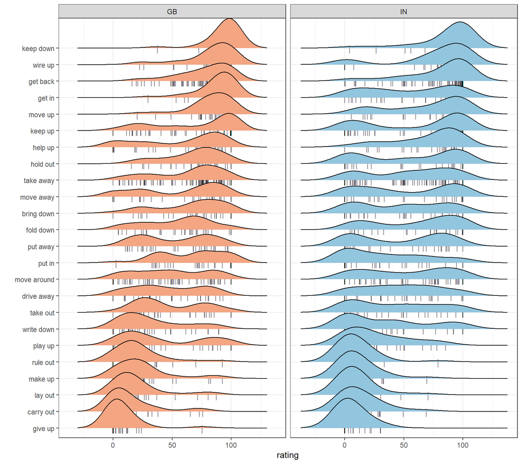

## 1.3 Patterns across individuals

One thing to note is that there is a fair amount of variation across participants, with a few (a21 and a46) not really using the full rating scale and making more of a binary choice.

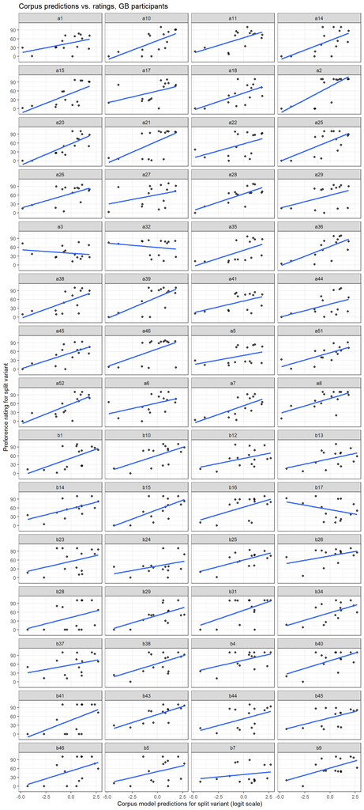

A similar trend shows up with the IN participants, but it’s perhaps even more common for participants to only use the end points. Some participants (idab017, idab021, idb009, idb011, idb019) are effectively treating this as a forced-choice task…

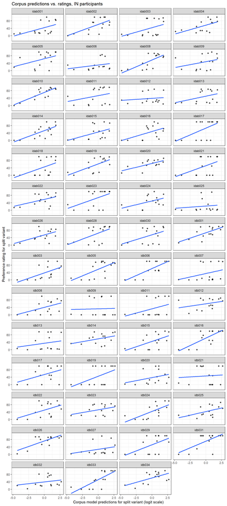

# 2 Models

## 2.1 Linear or GAMM models?

First we’ll consider whether we want to use a simpler linear model, or a more complex generalized additive model (GAM).

### 2.1.1 Linear mixed model

```r
summary(lmer1 <- lmer(
  rating_st ~ (1|item) + (1|id) + (0 + pred_min|id) + (z.DirObjWordLength + pred_min) * condition,
  data = rats2
  ))
```

```
Linear mixed model fit by REML ['lmerMod']
Formula:
rating_st ~ (1 | item) + (1 | id) + (0 + pred_min | id) + (z.DirObjWordLength +
    pred_min) * condition
   Data: rats2

REML criterion at convergence: 4094.6

Scaled residuals:
    Min      1Q  Median      3Q     Max
-3.0514 -0.6582  0.0396  0.6596  2.7515

Random effects:
 Groups   Name        Variance  Std.Dev.
 id       pred_min    0.0002529 0.0159
 id.1     (Intercept) 0.0375589 0.1938
 item     (Intercept) 0.1501932 0.3875
 Residual             0.5641203 0.7511
Number of obs: 1725, groups:  id, 115; item, 30

Fixed effects:
                                Estimate Std. Error t value
(Intercept)                     0.173686   0.081845   2.122
z.DirObjWordLength             -0.123055   0.047771  -2.576
pred_min                        0.234689   0.041229   5.692
conditionIN                    -0.188491   0.052209  -3.610
z.DirObjWordLength:conditionIN  0.031127   0.023183   1.343
pred_min:conditionIN            0.005639   0.020223   0.279

Correlation of Fixed Effects:
            (Intr) z.DrOWL prd_mn cndtIN z.DOWL:
z.DrObjWrdL -0.245
pred_min     0.021  0.206
conditionIN -0.305  0.041  -0.006
z.DrObWL:IN  0.055 -0.232  -0.049 -0.185
prd_mn:cnIN -0.007 -0.048  -0.234  0.016  0.212
```

Type II Wald tests suggest that `condition` and `z.DirObjWordLength` have significant effects, but there is no interaction effect.

```
Analysis of Deviance Table (Type II Wald chisquare tests)

Response: rating_st
                              Chisq Df Pr(>Chisq)
z.DirObjWordLength            5.418  1      0.020 *
pred_min                     35.079  1     <2e-16 ***
condition                    11.741  1      0.001 ***
z.DirObjWordLength:condition  1.803  1      0.179
pred_min:condition            0.078  1      0.780
---
Signif. codes:  0 '***' 0.001 '**' 0.01 '*' 0.05 '.' 0.1 ' ' 1
```

The effects plot illustrates the weak effect of DO length, such that as the DO gets longer, participants tend to favor the joined variant more, and it shows that British participants do tend to like the split variant slightly more than Indian participants. This difference by country holds regardless of DO length. There is a clear effect of model predictions.

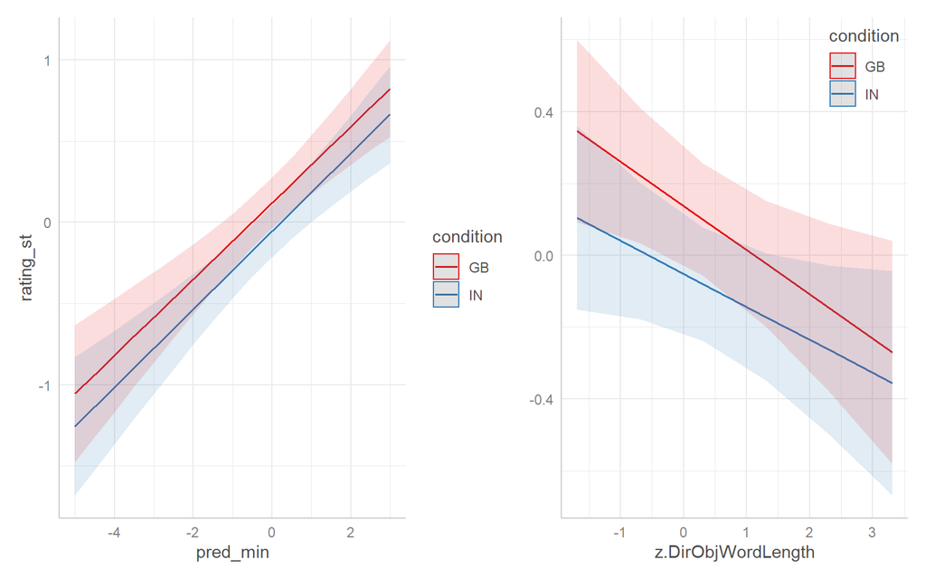

Now we check the model fit quickly using the really helpful `performance` package.

```r
model_performance(lmer1) %>% round(3)
```

```
# Indices of model performance

AIC     |     BIC | R2 (cond.) | R2 (marg.) |  ICC | RMSE | Sigma
-----------------------------------------------------------------
4114.59 | 4169.12 |       0.42 |       0.27 | 0.21 | 0.73 |  0.75
```

Not too good… The low marginal $R^2$ tells us that the fixed effects predictors aren’t that doing much. We can also look at the model diagnostics and see if we have any reason to worry.

```r
check_model(lmer1)
```

```
Could not compute standard errors from random effects for diagnostic plot.
```

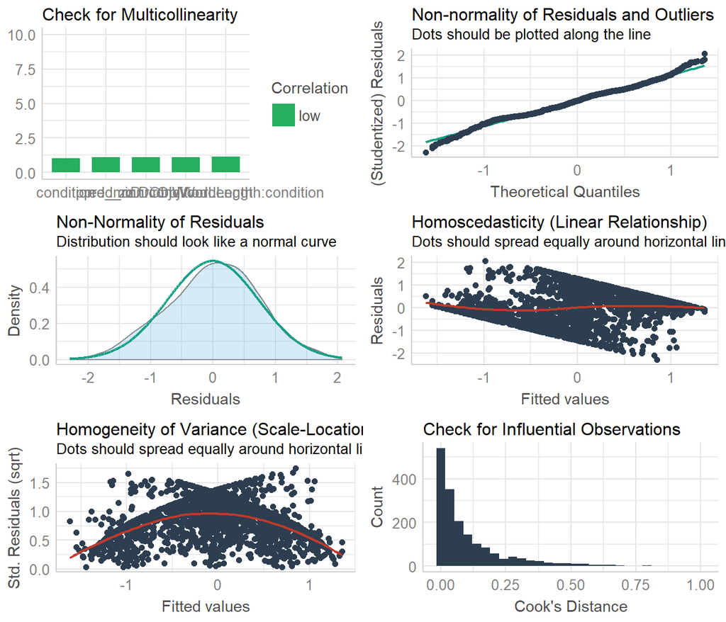

I don’t know… Mostly looks good, but there is a good deal of heteroskedasticity, which could be concerning. I’ll set that aside for now.

### 2.1.2 GAMM model

Check it out

```
Family: gaussian
Link function: identity

Formula:
rating_st ~ condition + s(z.DirObjWordLength, k = 4, by = condition) +
    s(pred_min, by = condition)

Parametric coefficients:
            Estimate Std. Error t value Pr(>|t|)
(Intercept)  0.08281    0.03535   2.343 0.019249 *
conditionIN -0.17306    0.05111  -3.386 0.000726 ***
---
Signif. codes:  0 '***' 0.001 '**' 0.01 '*' 0.05 '.' 0.1 ' ' 1

Approximate significance of smooth terms:
                                    edf Ref.df     F p-value
s(z.DirObjWordLength):conditionGB 1.000  1.000 82.18  <2e-16 ***
s(z.DirObjWordLength):conditionIN 2.533  2.533 20.93  <2e-16 ***
s(pred_min):conditionGB           8.085  8.085 38.66  <2e-16 ***
s(pred_min):conditionIN           8.259  8.259 37.33  <2e-16 ***
---
Signif. codes:  0 '***' 0.001 '**' 0.01 '*' 0.05 '.' 0.1 ' ' 1

R-sq.(adj) =  0.326
  Scale est. = 0.30696   n = 1725
```

Indian participants tend to prefer the continuous variation significantly more than GB participants, which is interesting. But this is only a small effect: only a difference of .17 standard deviations, which is about 6-7 points on our rating scale if my calculations are correct. There is *some* curvature in the `z.DirObjWordLength`, but not much. We could maybe leave this smoothing term out…

If we look at the smoothing terms, things go in the expected direction, with some wiggliness. Not sure whether we need to say much about this here.

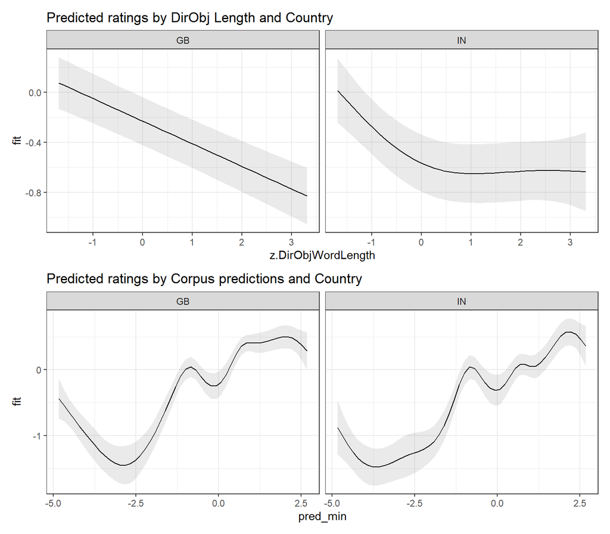

Checking the significance of interactions is tricky, but I’ll follow the method here: https://jacolienvanrij.com/Tutorials/GAMM.html#summary

```
Family: gaussian
Link function: identity

Formula:
rating_st ~ ordered_cond + s(z.DirObjWordLength, k = 4, by = ordered_cond) +
    s(pred_min, by = ordered_cond)

Parametric coefficients:
               Estimate Std. Error t value Pr(>|t|)
(Intercept)     0.11722    0.03559   3.294 0.001009 **
ordered_condIN -0.19981    0.05160  -3.872 0.000112 ***
---
Signif. codes:  0 '***' 0.001 '**' 0.01 '*' 0.05 '.' 0.1 ' ' 1

Approximate significance of smooth terms:
                                       edf Ref.df     F p-value
s(z.DirObjWordLength):ordered_condIN 2.568  2.568 20.98  <2e-16 ***
s(pred_min):ordered_condIN           8.114  8.114 15.58  <2e-16 ***
---
Signif. codes:  0 '***' 0.001 '**' 0.01 '*' 0.05 '.' 0.1 ' ' 1

R-sq.(adj) =  0.159
  Scale est. = 0.55205   n = 1725
```

If I understand this correctly, this suggests that GB and IN participants show significantly different trends in their ratings as the Direct Object gets longer, and a significantly different trend in their ratings as the corpus model probabilities for the split variant increase. These are pretty weak effects, however, so I’m inclined not to make too much out od these results. (And again, I may not be interpreting this correctly…)

## 2.2 Random effects

To be continued…

# 3 References

Barr, Dale J., Roger Levy, Christoph Scheepers & Harry J. Tly. 2013. Random Effects Structure for Confirmatory Hypothesis Testing: Keep It Maximal. *Journal of Memory and Language* 68. 255–278.

Bates, Douglas, Reinhold Kliegl, Shravan Vasishth & Harald Baayen. 2015. Parsimonious mixed models. *arXiv:1506.04967 [stat]*. http://arxiv.org/abs/1506.04967.

Matuschek, Hannes, Reinhold Kliegl, Shravan Vasishth, Harald Baayen & Douglas Bates. 2017. Balancing Type I error and power in linear mixed models. *Journal of Memory and Language* 94. 305–315. doi:10.1016/j.jml.2017.01.001.